# 27 기본 R 필드 가이드

## 27.1 소개

프로그래밍 섹션을 마무리하기 위해, 이 책에서 다루지 않은 가장 중요한 기본(base) R 함수들을 간단히 살펴보겠습니다. 이 도구들은 프로그래밍을 더 많이 할 때 특히 유용하며, 야생에서 만날 코드를 읽는 데 도움이 될 것입니다.

이 시점에서 tidyverse만이 데이터 과학 문제를 해결하는 유일한 방법이 아니라는 점을 상기시키는 것이 좋겠습니다. 이 책에서 tidyverse를 가르치는 이유는 tidyverse 패키지들이 공통된 디자인 철학을 공유하여 함수 간의 일관성을 높이고 새로운 함수나 패키지를 배우고 사용하기 조금 더 쉽게 만들기 때문입니다. 기본 R을 사용하지 않고는 tidyverse를 사용할 수 없으므로, 패키지를 로드하기 위한 `library()`, 수치 요약을 위한 `sum()`과 `mean()`, 팩터, 날짜, POSIXct 데이터 유형, 그리고 물론 `+`, `-`, `/`, `*`, `|`, `&`, `!`와 같은 모든 기본 연산자에 이르기까지 이미 **많은** 기본 R 함수를 가르쳐 드렸습니다. 지금까지 우리가 집중하지 않았던 것은 기본 R 워크플로우이므로, 이 장에서는 그 중 몇 가지를 강조할 것입니다.

이 책을 읽고 나면 기본 R, data.table 및 기타 패키지를 사용하여 동일한 문제에 대한 다른 접근 방식을 배우게 될 것입니다. 특히 StackOverflow를 사용하는 경우 다른 사람이 작성한 R 코드를 읽기 시작할 때 의심할 여지 없이 이러한 다른 접근 방식을 접하게 될 것입니다. 다양한 접근 방식을 혼합하여 코드를 작성하는 것은 100% 괜찮습니다. 다른 사람의 말에 휘둘리지 마세요!

이 장에서는 `[`를 사용한 부분집합, `[[`와 `$`를 사용한 부분집합, apply 계열 함수, `for` 루프라는 네 가지 큰 주제에 중점을 둘 것입니다. 마지막으로 두 가지 필수 플롯 함수에 대해 간단히 설명하겠습니다.

### 27.1.1 선수 지식

이 장은 기본 R에 중점을 두므로 실제 전제 조건은 없지만, 차이점 중 일부를 설명하기 위해 tidyverse를 로드할 것입니다.

```r
library(tidyverse)
```

## 27.2 `[`로 여러 요소 선택하기

`[`는 벡터와 데이터 프레임에서 하위 구성 요소를 추출하는 데 사용되며 `x[i]` 또는 `x[i, j]`와 같이 호출됩니다. 이 섹션에서는 `[`의 힘을 소개합니다. 먼저 벡터와 함께 사용하는 방법을 보여준 다음, 데이터 프레임과 같은 2차원(2d) 구조로 동일한 원리가 어떻게 간단하게 확장되는지 보여줍니다. 그런 다음 다양한 dplyr 동사가 `[`의 특수한 경우임을 보여줌으로써 지식을 굳히는 데 도움을 줄 것입니다.

### 27.2.1 벡터 부분집합하기

벡터를 부분집합할 수 있는, 즉 `x[i]`에서 `i`가 될 수 있는 주요 유형은 다섯 가지입니다:

1. **양의 정수 벡터**. 양의 정수로 부분집합하면 해당 위치의 요소가 유지됩니다:

   ```r
   x <- c("one", "two", "three", "four", "five")
   x[c(3, 2, 5)]
   ```

   ```
   #> [1] "three" "two"   "five"
   ```

   위치를 반복함으로써 실제로 입력보다 더 긴 출력을 만들 수 있으므로 “부분집합”이라는 용어는 다소 부적절할 수 있습니다.

   ```r
   x[c(1, 1, 5, 5, 5, 2)]
   ```

   ```
   #> [1] "one"  "one"  "five" "five" "five" "two"
   ```

2. **음의 정수 벡터**. 음수 값은 지정된 위치의 요소를 삭제합니다:

   ```r
   x[c(-1, -3, -5)]
   ```

   ```
   #> [1] "two"  "four"
   ```

3. **논리형 벡터**. 논리형 벡터로 부분집합하면 `TRUE` 값에 해당하는 모든 값이 유지됩니다. 이것은 비교 함수와 함께 사용할 때 가장 유용합니다.

   ```r
   x <- c(10, 3, NA, 5, 8, 1, NA)

   # x의 모든 결측되지 않은 값
   x[!is.na(x)]
   ```

   ```
   #> [1] 10  3  5  8  1
   ```

   ```r
   # x의 모든 짝수(또는 결측!) 값
   x[x %% 2 == 0]
   ```

   ```
   #> [1] 10 NA  8 NA
   ```

   `filter()`와 달리 `NA` 인덱스는 출력에 `NA`로 포함됩니다.
4. **문자형 벡터**. 명명된 벡터가 있는 경우 문자형 벡터로 부분집합할 수 있습니다:

   ```r
   x <- c(abc = 1, def = 2, xyz = 5)
   x[c("xyz", "def")]
   ```

   ```
   #> xyz def
   #>   5   2
   ```

   양의 정수로 부분집합하는 것과 마찬가지로 문자형 벡터를 사용하여 개별 항목을 복제할 수 있습니다.
5. **없음**. 마지막 유형의 부분집합은 아무것도 없는 `x[]`이며, 이는 완전한 `x`를 반환합니다. 이것은 벡터를 부분집합하는 데는 유용하지 않지만, 곧 보게 되겠지만 티블과 같은 2차원 구조를 부분집합할 때 유용합니다.

### 27.2.2 데이터 프레임 부분집합하기

데이터 프레임과 함께 `[`를 사용할 수 있는 꽤 다양한 방법[^1]이 있지만, 가장 중요한 방법은 `df[rows, cols]`로 행과 열을 독립적으로 선택하는 것입니다. 여기서 `rows`와 `cols`는 위에서 설명한 벡터입니다. 예를 들어 `df[rows, ]`와 `df[, cols]`는 행만 선택하거나 열만 선택하며, 빈 부분집합을 사용하여 다른 차원을 보존합니다.

다음은 몇 가지 예입니다:

```r
df <- tibble(
  x = 1:3,
  y = c("a", "e", "f"),
  z = runif(3)
)

# 첫 번째 행과 두 번째 열 선택
df[1, 2]
```

```
#> # A tibble: 1 × 1
#>   y
#>   <chr>
#> 1 a
```

```r
# 모든 행과 x, y 열 선택
df[, c("x" , "y")]
```

```
#> # A tibble: 3 × 2
#>       x y
#>   <int> <chr>
#> 1     1 a
#> 2     2 e
#> 3     3 f
```

```r
# `x`가 1보다 큰 행과 모든 열 선택
df[df$x > 1, ]
```

```
#> # A tibble: 2 × 3
#>       x y         z
#>   <int> <chr> <dbl>
#> 1     2 e     0.834
#> 2     3 f     0.601
```

곧 `$`로 돌아오겠지만 문맥상 `df$x`가 무엇을 하는지 짐작할 수 있을 것입니다: `df`에서 `x` 변수를 추출합니다. 여기서 `[`는 tidy evaluation을 사용하지 않으므로 `x` 변수의 출처를 명시해야 하기 때문에 이것을 사용해야 합니다.

`[`와 관련하여 티블과 데이터 프레임 사이에는 중요한 차이점이 있습니다. 이 책에서 우리는 주로 티블을 사용했는데, 티블은 데이터 프레임이지만 삶을 조금 더 쉽게 만들기 위해 일부 동작을 조정합니다. 대부분의 경우 “티블”과 “데이터 프레임”을 상호 교환적으로 사용할 수 있으므로 R의 내장 데이터 프레임에 특히 주의를 기울이고 싶을 때 `data.frame`이라고 쓸 것입니다. `df`가 `data.frame`인 경우 `df[, cols]`는 `col`이 단일 열을 선택하면 벡터를 반환하고 둘 이상의 열을 선택하면 데이터 프레임을 반환합니다. `df`가 티블이면 `[`는 항상 티블을 반환합니다.

```r
df1 <- data.frame(x = 1:3)
df1[, "x"]
```

```
#> [1] 1 2 3
```

```r
df2 <- tibble(x = 1:3)
df2[, "x"]
```

```
#> # A tibble: 3 × 1
#>       x
#>   <int>
#> 1     1
#> 2     2
#> 3     3
```

`data.frame`의 이러한 모호성을 피하는 한 가지 방법은 `drop = FALSE`를 명시적으로 지정하는 것입니다:

```r
df1[, "x" , drop = FALSE]
```

```
#>   x
#> 1 1
#> 2 2
#> 3 3
```

### 27.2.3 dplyr 등가물

여러 dplyr 동사는 `[`의 특수한 경우입니다:

- `filter()`는 결측값을 제외하도록 주의하면서 논리형 벡터로 행을 부분집합하는 것과 같습니다:

  ```r
  df <- tibble(
    x = c(2, 3, 1, 1, NA),
    y = letters[1:5],
    z = runif(5)
  )
  df |> filter(x > 1)

  # 다음은 동일함
  df[!is.na(df$x) & df$x > 1, ]
  ```

  야생에서 흔히 볼 수 있는 또 다른 기술은 결측값을 삭제하는 부작용을 위해 `which()`를 사용하는 것입니다: `df[which(df$x > 1), ]`.
- `arrange()`는 정수 벡터로 행을 부분집합하는 것과 같으며, 보통 `order()`로 생성됩니다:

  ```r
  df |> arrange(x, y)

  # 다음은 동일함
  df[order(df$x, df$y), ]
  ```

  `order(decreasing = TRUE)`를 사용하여 모든 열을 내림차순으로 정렬하거나 `-rank(col)`을 사용하여 개별적으로 열을 내림차순으로 정렬할 수 있습니다.
- `select()`와 `relocate()`는 모두 문자형 벡터로 열을 부분집합하는 것과 비슷합니다:

  ```r
  df |> select(x, z)

  # 다음은 동일함
  df[, c("x", "z")]
  ```

기본 R은 `subset()`이라는 `filter()`와 `select()`[^2]의 기능을 결합한 함수도 제공합니다:

```r
df |>
  filter(x > 1) |>
  select(y, z)
```

```
#> # A tibble: 2 × 2
#>   y           z
#>   <chr>   <dbl>
#> 1 a     0.157
#> 2 b     0.00740
```

```r
# 다음은 동일함
df |> subset(x > 1, c(y, z))
```

이 함수는 dplyr 구문의 많은 부분에 영감을 주었습니다.

### 27.2.4 연습문제

1. 벡터를 입력으로 받아 다음을 반환하는 함수를 만드세요:
   1. 짝수 위치에 있는 요소.
   2. 마지막 값을 제외한 모든 요소.
   3. 짝수 값만(결측값 없음).
2. `x[-which(x > 0)]`이 `x[x <= 0]`과 같지 않은 이유는 무엇입니까? `which()`에 대한 문서를 읽고 실험을 통해 알아내세요.

## 27.3 `$`와 `[[`로 단일 요소 선택하기

많은 요소를 선택하는 `[`는 단일 요소를 추출하는 `[[` 및 `$`와 짝을 이룹니다. 이 섹션에서는 `[[`와 `$`를 사용하여 데이터 프레임에서 열을 뽑아내는 방법을 보여주고, `data.frame`과 티블 간의 몇 가지 차이점에 대해 논의하며, 리스트와 함께 사용할 때 `[`와 `[[`의 중요한 차이점을 강조합니다.

### 27.3.1 데이터 프레임

`[[`와 `$`는 데이터 프레임에서 열을 추출하는 데 사용할 수 있습니다. `[[`는 위치나 이름으로 액세스할 수 있으며 `$`는 이름에 의한 액세스에 특화되어 있습니다:

```r
tb <- tibble(
  x = 1:4,
  y = c(10, 4, 1, 21)
)

# 위치로
tb[[1]]
```

```
#> [1] 1 2 3 4
```

```r
# 이름으로
tb[["x"]]
```

```
#> [1] 1 2 3 4
```

```r
tb$x
```

```
#> [1] 1 2 3 4
```

또한 기본 R에서 `mutate()`에 해당하는 새로운 열을 만드는 데에도 사용할 수 있습니다:

```r
tb$z <- tb$x + tb$y
tb
```

```
#> # A tibble: 4 × 3
#>       x     y     z
#>   <int> <dbl> <dbl>
#> 1     1    10    11
#> 2     2     4     6
#> 3     3     1     4
#> 4     4    21    25
```

`transform()`, `with()`, `within()`을 포함하여 새 열을 만드는 다른 여러 기본 R 접근 방식이 있습니다. Hadley는 https://gist.github.com/hadley/1986a273e384fb2d4d752c18ed71bedf에 몇 가지 예제를 모았습니다.

빠른 요약을 수행할 때 `$`를 직접 사용하는 것이 편리합니다. 예를 들어 가장 큰 다이아몬드의 크기나 `cut`의 가능한 값을 찾고 싶다면 `summarize()`를 사용할 필요가 없습니다:

```r
max(diamonds$carat)
```

```
#> [1] 5.01
```

```r
levels(diamonds$cut)
```

```
#> [1] "Fair"      "Good"      "Very Good" "Premium"   "Ideal"
```

dplyr는 Chapter 3 에서 언급하지 않은 `[[`/`$`에 해당하는 `pull()`을 제공합니다. `pull()`은 변수 이름이나 변수 위치를 취하고 해당 열만 반환합니다. 즉, 위의 코드를 파이프를 사용하도록 다시 쓸 수 있습니다:

```r
diamonds |> pull(carat) |> max()
```

```
#> [1] 5.01
```

```r
diamonds |> pull(cut) |> levels()
```

```
#> [1] "Fair"      "Good"      "Very Good" "Premium"   "Ideal"
```

### 27.3.2 티블

`$`와 관련하여 티블과 기본 `data.frame` 사이에는 몇 가지 중요한 차이점이 있습니다. 데이터 프레임은 변수 이름의 접두사를 일치시키고(**부분 일치**라고 함) 열이 존재하지 않아도 불평하지 않습니다:

```r
df <- data.frame(x1 = 1)
df$x
```

```
#> [1] 1
```

```r
df$z
```

[output not shown]

```r
tb <- tibble(x1 = 1)

tb$x
```

```
#> Warning: Unknown or uninitialised column: `x`.
#> NULL
```

```r
tb$z
```

```
#> Warning: Unknown or uninitialised column: `z`.
#> NULL
```

이런 이유로 우리는 때때로 티블이 게으르고 무뚝뚝하다고 농담합니다: 덜 일하고 더 많이 불평합니다.

### 27.3.3 리스트

`[[`와 `$`는 리스트 작업에도 정말 중요하며 `[`와 어떻게 다른지 이해하는 것이 중요합니다. `l`이라는 이름의 리스트로 차이점을 설명해 보겠습니다:

```r
l <- list(
  a = 1:3,
  b = "a string",
  c = pi,
  d = list(-1, -5)
)
```

- `[`는 하위 리스트를 추출합니다. 추출하는 요소의 수에 관계없이 결과는 항상 리스트입니다.

  ```r
  str(l[1:2])
  ```

  ```
  #> List of 2
  #>  $ a: int [1:3] 1 2 3
  #>  $ b: chr "a string"
  ```

  ```r
  str(l[1])
  ```

  ```
  #> List of 1
  #>  $ a: int [1:3] 1 2 3
  ```

  ```r
  str(l[4])
  ```

  ```
  #> List of 1
  #>  $ d:List of 2
  #>   ..$ : num -1
  #>   ..$ : num -5
  ```

  벡터와 마찬가지로 논리형, 정수형 또는 문자형 벡터로 부분집합할 수 있습니다.
- `[[`와 `$`는 리스트에서 단일 구성 요소를 추출합니다. 그들은 리스트에서 계층 구조의 한 수준을 제거합니다.

  ```r
  str(l[[1]])
  ```

  ```
  #>  int [1:3] 1 2 3
  ```

  ```r
  str(l[[4]])
  ```

  ```
  #> List of 2
  #>  $ : num -1
  #>  $ : num -5
  ```

  ```r
  str(l$a)
  ```

  ```
  #>  int [1:3] 1 2 3
  ```

`[`와 `[[`의 차이점은 리스트의 경우 특히 중요합니다. `[[`는 리스트를 파고드는 반면 `[`는 새롭고 더 작은 리스트를 반환하기 때문입니다. 차이점을 기억하는 데 도움이 되도록 Figure 27.1 에 표시된 특이한 후추통을 살펴보세요. 이 후추통이 리스트 `pepper`라면 `pepper[1]`은 단일 후추 패킷이 들어 있는 후추통입니다. `pepper[2]`는 똑같이 보이지만 두 번째 패킷이 들어 있을 것입니다. `pepper[1:2]`는 두 개의 후추 패킷이 들어 있는 후추통일 것입니다. `pepper[[1]]`은 후추 패킷 자체를 추출합니다.

[figure not shown]

Figure 27.1: (왼쪽) Hadley가 호텔 방에서 한 번 발견한 후추통. (가운데) `pepper[1]`. (오른쪽) `pepper[[1]]`

데이터 프레임에 1차원 `[`를 사용할 때도 동일한 원칙이 적용됩니다: `df["x"]`는 1열 데이터 프레임을 반환하고 `df[["x"]]`는 벡터를 반환합니다.

### 27.3.4 연습문제

1. 벡터의 길이보다 큰 양의 정수로 `[[`를 사용하면 어떻게 됩니까? 존재하지 않는 이름으로 부분집합하면 어떻게 됩니까?
2. `pepper[[1]][1]`은 무엇일까요? `pepper[[1]][[1]]`은 어떻습니까?

## 27.4 Apply 계열

Chapter 26 에서 `dplyr::across()` 및 map 함수 계열과 같은 반복을 위한 tidyverse 기술을 배웠습니다. 이 섹션에서는 이들의 기본 등가물인 **apply 계열**에 대해 배울 것입니다. 이 문맥에서 apply와 map은 동의어입니다. “벡터의 각 요소에 함수를 매핑”하는 것을 “벡터의 각 요소에 함수를 적용(apply)”한다고 말할 수 있기 때문입니다. 여기서는 야생에서 이들을 인식할 수 있도록 이 계열에 대한 빠른 개요를 제공합니다.

이 계열의 가장 중요한 멤버는 `lapply()`이며, 이는 `purrr::map()`[^3]과 매우 유사합니다. 실제로 `map()`의 고급 기능을 사용하지 않았기 때문에 Chapter 26 의 모든 `map()` 호출을 `lapply()`로 바꿀 수 있습니다.

`across()`에 해당하는 정확한 기본 R 등가물은 없지만 `lapply()`와 함께 `[`를 사용하여 근접하게 할 수 있습니다. 이것이 작동하는 이유는 내부적으로 데이터 프레임이 열의 리스트이기 때문에 데이터 프레임에서 `lapply()`를 호출하면 각 열에 함수가 적용되기 때문입니다.

```r
df <- tibble(a = 1, b = 2, c = "a", d = "b", e = 4)

# 먼저 수치형 열 찾기
num_cols <- sapply(df, is.numeric)
num_cols
```

```
#>     a     b     c     d     e
#>  TRUE  TRUE FALSE FALSE  TRUE
```

```r
# 그런 다음 lapply()로 각 열을 변환한 다음 원래 값을 대체
df[, num_cols] <- lapply(df[, num_cols, drop = FALSE], \(x) x * 2)
df
```

```
#> # A tibble: 1 × 5
#>       a     b c     d         e
#>   <dbl> <dbl> <chr> <chr> <dbl>
#> 1     2     4 a     b         8
```

위의 코드는 새로운 함수 `sapply()`를 사용합니다. `lapply()`와 비슷하지만 항상 결과를 단순화하려고 시도하므로 이름에 `s`가 붙어 있습니다. 여기서는 리스트 대신 논리형 벡터를 생성합니다. 단순화가 실패하여 예상치 못한 유형을 제공할 수 있으므로 프로그래밍에는 사용하지 않는 것이 좋지만 대화형 사용에는 일반적으로 괜찮습니다. purrr에는 Chapter 26 에서 언급하지 않은 `map_vec()`이라는 유사한 함수가 있습니다.

기본 R은 `vapply()`라는 `sapply()`의 더 엄격한 버전을 제공합니다. 이는 **v**ector apply의 줄임말입니다. 이것은 예상되는 유형을 지정하는 추가 인수를 취하여 입력에 관계없이 동일한 방식으로 단순화가 발생하도록 합니다. 예를 들어 위의 `sapply()` 호출을 `is.numeric()`이 길이 1의 논리형 벡터를 반환할 것으로 예상한다고 지정하는 이 `vapply()`로 바꿀 수 있습니다:

```r
vapply(df, is.numeric, logical(1))
```

```
#>     a     b     c     d     e
#>  TRUE  TRUE FALSE FALSE  TRUE
```

`sapply()`와 `vapply()`의 구별은 함수 내부에 있을 때 정말 중요하지만(비정상적인 입력에 대한 함수의 견고성에 큰 차이를 만들기 때문입니다), 데이터 분석에서는 일반적으로 중요하지 않습니다.

apply 계열의 또 다른 중요한 멤버는 단일 그룹화된 요약을 계산하는 `tapply()`입니다:

```r
diamonds |>
  group_by(cut) |>
  summarize(price = mean(price))
```

```
#> # A tibble: 5 × 2
#>   cut       price
#>   <ord>     <dbl>
#> 1 Fair      4359.
#> 2 Good      3929.
#> 3 Very Good 3982.
#> 4 Premium   4584.
#> 5 Ideal     3458.
```

```r
tapply(diamonds$price, diamonds$cut, mean)
```

```
#>      Fair      Good Very Good   Premium     Ideal
#>  4358.758  3928.864  3981.760  4584.258  3457.542
```

불행히도 `tapply()`는 결과를 명명된 벡터로 반환하므로 여러 요약 및 그룹화 변수를 데이터 프레임으로 수집하려면 약간의 체조가 필요합니다(이렇게 하지 않고 자유 부동 벡터로 작업하는 것은 확실히 가능하지만 경험상 작업이 지연될 뿐입니다). `tapply()` 또는 기타 기본 기술을 사용하여 다른 그룹화된 요약을 수행하는 방법을 보고 싶다면 Hadley가 [gist](https://gist.github.com/hadley/c430501804349d382ce90754936ab8ec)에 몇 가지 기술을 모아두었습니다.

apply 계열의 마지막 멤버는 행렬 및 배열과 함께 작동하는 이름 그대로의 `apply()`입니다. 특히 `lapply(df, something)`을 수행하는 느리고 잠재적으로 위험한 방법인 `apply(df, 2, something)`을 주의하세요. 우리는 일반적으로 행렬이 아닌 데이터 프레임으로 작업하기 때문에 데이터 과학에서는 거의 나타나지 않습니다.

## 27.5 `for` 루프

`for` 루프는 apply 및 map 계열 모두 내부적으로 사용하는 반복의 기본 구성 요소입니다. `for` 루프는 더 경험이 많은 R 프로그래머가 됨에 따라 배워야 할 강력하고 일반적인 도구입니다. `for` 루프의 기본 구조는 다음과 같습니다:

```r
for (element in vector) {
  # 요소로 무언가를 수행
}
```

`for` 루프의 가장 간단한 사용은 `walk()`와 동일한 효과를 얻는 것입니다: 리스트의 각 요소에 대해 부작용이 있는 함수를 호출합니다. 예를 들어, Section 26.4.1 에서 `walk()`를 사용하는 대신:

```r
paths |> walk(append_file)
```

`for` 루프를 사용할 수 있었습니다:

```r
for (path in paths) {
  append_file(path)
}
```

`for` 루프의 출력을 저장하려는 경우, 예를 들어 Chapter 26 에서와 같이 디렉토리의 모든 엑셀 파일을 읽으려는 경우 상황이 조금 더 까다로워집니다:

```r
paths <- dir("data/gapminder", pattern = "\\.xlsx$", full.names = TRUE)
files <- map(paths, readxl::read_excel)
```

사용할 수 있는 몇 가지 다른 기술이 있지만, 출력이 어떻게 보일지 미리 명시하는 것이 좋습니다. 이 경우 `paths`와 길이가 같은 리스트를 원하므로 `vector()`로 만들 수 있습니다:

```r
files <- vector("list", length(paths))
```

그런 다음 `paths`의 요소를 반복하는 대신 `seq_along()`을 사용하여 paths의 각 요소에 대한 하나의 인덱스를 생성하여 인덱스를 반복합니다:

```r
seq_along(paths)
```

```
#>  [1]  1  2  3  4  5  6  7  8  9 10 11 12
```

인덱스를 사용하는 것은 입력의 각 위치를 출력의 해당 위치와 연결할 수 있기 때문에 중요합니다:

```r
for (i in seq_along(paths)) {
  files[[i]] <- readxl::read_excel(paths[[i]])
}
```

티블 리스트를 단일 티블로 결합하려면 `do.call()` + `rbind()`를 사용할 수 있습니다:

```r
do.call(rbind, files)
```

```
#> # A tibble: 1,704 × 5
#>   country     continent lifeExp      pop gdpPercap
#>   <chr>       <chr>       <dbl>    <dbl>     <dbl>
#> 1 Afghanistan Asia         28.8  8425333      779.
#> 2 Albania     Europe       55.2  1282697     1601.
#> 3 Algeria     Africa       43.1  9279525     2449.
#> 4 Angola      Africa       30.0  4232095     3521.
#> 5 Argentina   Americas     62.5 17876956     5911.
#> 6 Australia   Oceania      69.1  8691212    10040.
#> # ℹ 1,698 more rows
```

리스트를 만들고 진행하면서 결과를 저장하는 대신, 데이터 프레임을 조각별로 쌓아 올리는 더 간단한 접근 방식이 있습니다:

```r
out <- NULL
for (path in paths) {
  out <- rbind(out, readxl::read_excel(path))
}
```

벡터가 매우 길어지면 매우 느려질 수 있으므로 이 패턴은 피하는 것이 좋습니다. 이것이 `for` 루프가 느리다는 지속적인 헛소문의 원인입니다: 루프가 아니라 벡터를 반복적으로 키우는 것이 느린 것입니다.

## 27.6 플롯

그렇지 않으면 tidyverse를 사용하지 않는 많은 R 사용자가 합리적인 기본값, 자동 범례, 현대적인 모양과 같은 유용한 기능 때문에 플롯을 위해 ggplot2를 선호합니다. 그러나 기본 R 플롯 함수는 매우 간결하기 때문에 여전히 유용할 수 있습니다 — 기본 탐색 플롯을 수행하는 데 입력이 거의 필요하지 않습니다.

야생에서 볼 수 있는 두 가지 주요 유형의 기본 플롯은 각각 `plot()`과 `hist()`로 생성되는 산점도와 히스토그램입니다. 다음은 diamonds 데이터셋의 간단한 예입니다:

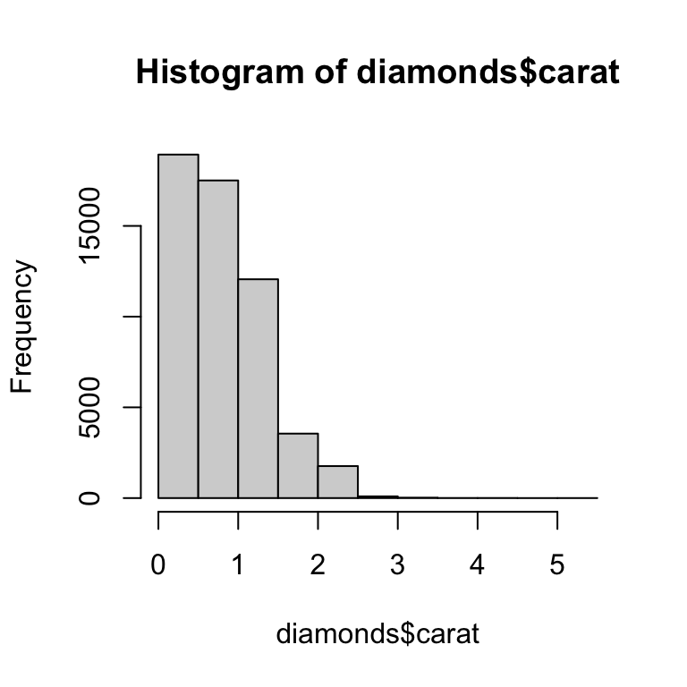

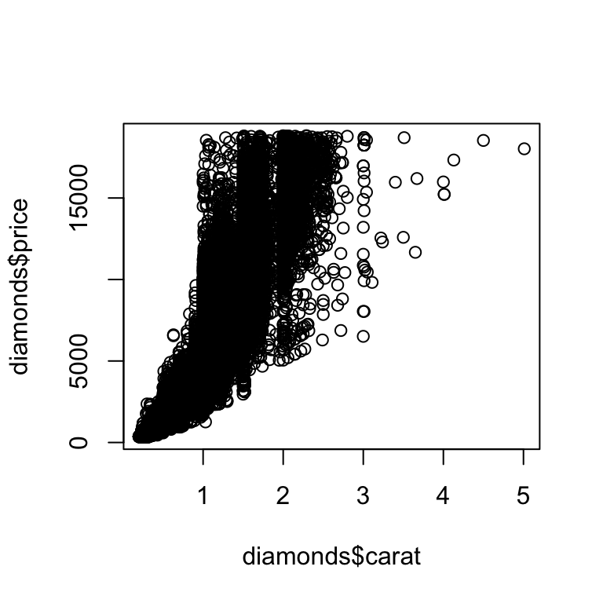

```r
# 왼쪽
hist(diamonds$carat)

# 오른쪽
plot(diamonds$carat, diamonds$price)
```

기본 플롯 함수는 벡터와 함께 작동하므로 `$` 또는 다른 기술을 사용하여 데이터 프레임에서 열을 뽑아내야 합니다.

## 27.7 요약

이 장에서는 부분집합 및 반복에 유용한 기본 R 함수들을 보여주었습니다. 책의 다른 곳에서 논의된 접근 방식과 비교할 때, 이러한 함수는 데이터 프레임과 일부 열 사양보다는 개별 벡터를 취하는 경향이 있기 때문에 “데이터 프레임” 풍미보다는 “벡터” 풍미가 더 강합니다. 이것은 종종 프로그래밍을 더 쉽게 만들므로 더 많은 함수를 작성하고 자신의 패키지를 작성하기 시작할 때 더 중요해집니다.

이 장으로 책의 프로그래밍 섹션이 끝납니다. 여러분은 R을 사용하는 데이터 과학자가 될 뿐만 아니라 R로 *프로그래밍*할 수 있는 데이터 과학자가 되는 여정의 확실한 시작을 했습니다. 이 장들이 프로그래밍에 대한 관심을 불러일으켰고 이 책 밖에서 더 배우기를 고대하고 있기를 바랍니다.

[^1]: https://adv-r.hadley.nz/subsetting.html#subset-multiple을 읽어보고 데이터 프레임을 1차원 객체처럼 부분집합하는 방법과 행렬로 부분집합하는 방법을 확인하세요.
[^2]: 하지만 그룹화된 데이터 프레임을 다르게 처리하지 않으며 `starts_with()`와 같은 선택 도우미 함수를 지원하지 않습니다.
[^3]: 진행률 표시줄과 오류 발생 시 문제가 발생한 요소를 보고하는 것과 같은 편리한 기능만 없습니다.